# Assignment-5-Neural-Networks

# Visualizing Performance

Based on ROC_AUC it seems that lower hidden unit and lower penalty generates the best model

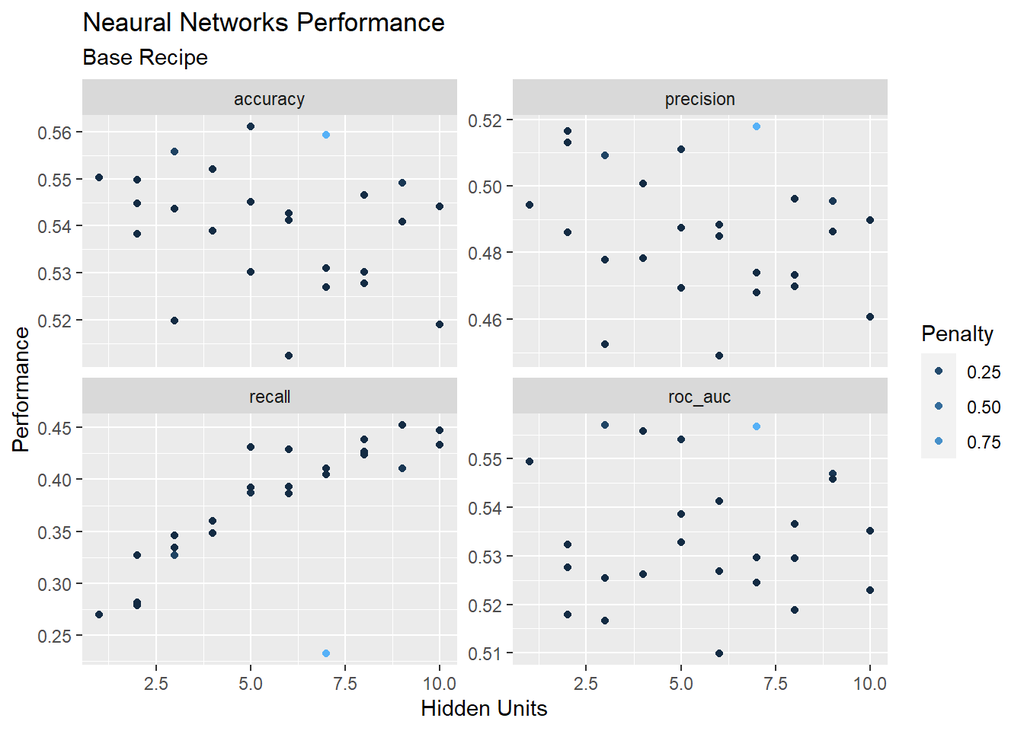

```r
neuralnetworks_base_tune%>%
collect_metrics()%>%
ggplot(aes(x = hidden_units, y = mean,color=penalty)) +
  geom_point() +
  facet_wrap(~.metric, scales = "free_y") +
  guides(colour = guide_legend(title = 'Penalty')) +
  labs(title = "Neaural Networks Performance",
       subtitle = "Base Recipe",
       x = "Hidden Units", y = "Performance")
```

Using `show_best` to view model performance based on optimization metric

```r
neuralnetworks_base_tune %>%
  show_best(metric = "roc_auc") %>%
  kable(digits = 3)
```

| hidden_units | penalty | .metric | .estimator | mean | n | std_err | .config |
| --- | --- | --- | --- | --- | --- | --- | --- |
| 3 | 0.190 | roc_auc | binary | 0.557 | 30 | 0.010 | Preprocessor1_Model25 |
| 7 | 0.973 | roc_auc | binary | 0.557 | 30 | 0.009 | Preprocessor1_Model23 |
| 4 | 0.000 | roc_auc | binary | 0.556 | 30 | 0.012 | Preprocessor1_Model11 |
| 5 | 0.049 | roc_auc | binary | 0.554 | 30 | 0.008 | Preprocessor1_Model15 |
| 1 | 0.011 | roc_auc | binary | 0.550 | 30 | 0.009 | Preprocessor1_Model10 |

Using `select_best` to isolate the best model

```r
neuralnetworks_base_tune %>%
  select_best(metric = "roc_auc")%>%
  kable(digits = 3)
```

| hidden_units | penalty | .config |
| --- | --- | --- |
| 3 | 0.19 | Preprocessor1_Model25 |

Pulling all metrics for the best model

```r
neuralnetworks_base_metric%>%
  subset(.config == 'Preprocessor1_Model25')%>%
  kable(digits = 3)
```

| hidden_units | penalty | .metric | .estimator | mean | n | std_err | .config |
| --- | --- | --- | --- | --- | --- | --- | --- |
| 3 | 0.19 | accuracy | binary | 0.556 | 30 | 0.010 | Preprocessor1_Model25 |
| 3 | 0.19 | precision | binary | 0.509 | 30 | 0.017 | Preprocessor1_Model25 |
| 3 | 0.19 | recall | binary | 0.327 | 30 | 0.012 | Preprocessor1_Model25 |
| 3 | 0.19 | roc_auc | binary | 0.557 | 30 | 0.010 | Preprocessor1_Model25 |

Same process as mentioned above for base recipe was applied to the Enhanced Recipe

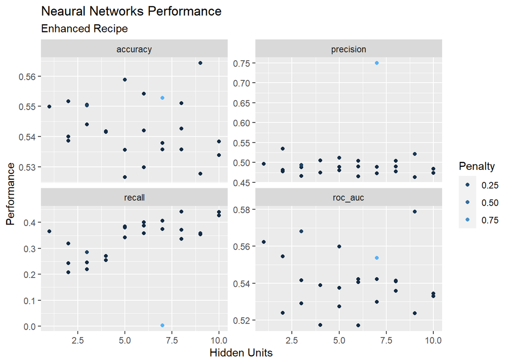

```r
neuralnetworks_enhanced_tune%>%
collect_metrics()%>%
ggplot(aes(x = hidden_units, y = mean,color=penalty)) +
  geom_point() +
  facet_wrap(~.metric, scales = "free_y") +
  guides(colour = guide_legend(title = 'Penalty')) +
  labs(title = "Neaural Networks Performance",
       subtitle = "Enhanced Recipe",
       x = "Hidden Units", y = "Performance")
```

```r
neuralnetworks_enhanced_tune %>%
  show_best(metric = "roc_auc") %>%
  kable(digits = 3)
```

| hidden_units | penalty | .metric | .estimator | mean | n | std_err | .config |
| --- | --- | --- | --- | --- | --- | --- | --- |
| 9 | 0.101 | roc_auc | binary | 0.579 | 30 | 0.011 | Preprocessor1_Model09 |
| 3 | 0.190 | roc_auc | binary | 0.568 | 30 | 0.010 | Preprocessor1_Model25 |
| 1 | 0.011 | roc_auc | binary | 0.562 | 30 | 0.010 | Preprocessor1_Model10 |
| 5 | 0.049 | roc_auc | binary | 0.560 | 30 | 0.011 | Preprocessor1_Model15 |
| 2 | 0.000 | roc_auc | binary | 0.555 | 30 | 0.010 | Preprocessor1_Model13 |

```r
neuralnetworks_enhanced_tune %>%
  select_best(metric = "roc_auc")%>%
  kable(digits = 3)
```

| hidden_units | penalty | .config |
| --- | --- | --- |
| 9 | 0.101 | Preprocessor1_Model09 |

```r
neuralnetworks_enhanced_metric%>%
  subset(.config == 'Preprocessor1_Model09')%>%
  kable(digits = 3)
```

| hidden_units | penalty | .metric | .estimator | mean | n | std_err | .config |
| --- | --- | --- | --- | --- | --- | --- | --- |
| 9 | 0.101 | accuracy | binary | 0.564 | 30 | 0.007 | Preprocessor1_Model09 |
| 9 | 0.101 | precision | binary | 0.521 | 30 | 0.012 | Preprocessor1_Model09 |
| 9 | 0.101 | recall | binary | 0.358 | 30 | 0.011 | Preprocessor1_Model09 |
| 9 | 0.101 | roc_auc | binary | 0.579 | 30 | 0.011 | Preprocessor1_Model09 |

# Findings

Based on optimization metrics 0.557 (Base Recipe) vs 0.579 (Enhanced Recipe), the enhanced recipe shows a better performance. For illustrative purpose feature importance of both recipe is shown below. Insights will be discussed more in Summary Report

# Feature Importance

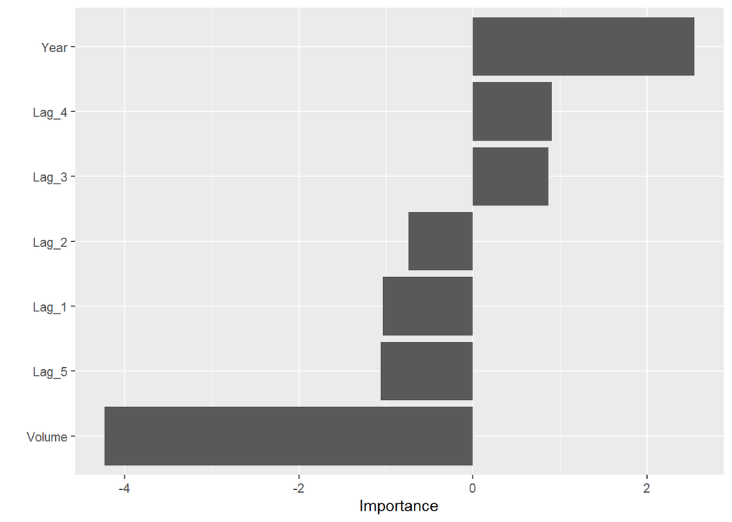

```r
best_base_model<-
    mlp(hidden_units = 3,
            penalty = 0.19) %>%
    set_mode(('classification')) %>%
    set_engine('nnet',importance = "impurity")

best_base_wf<-
  neuralnetworks_base_wf%>%
  update_model(best_base_model)

best_base_fit<-
  best_base_wf%>%
  last_fit(data_split)

best_base_fit%>%
  extract_fit_parsnip()%>%
  vip()
```

```r
best_enhanced_model<-
    mlp(hidden_units = 9,
          penalty = 0.101) %>%
    set_mode(('classification')) %>%
    set_engine('nnet',importance = "impurity")

best_enhanced_wf<-
  neuralnetworks_enhanced_wf%>%
  update_model(best_enhanced_model)

best_enhanced_fit<-
  best_enhanced_wf%>%
  last_fit(data_split)
```

```
## ! train/test split: preprocessor 1/1, model 1/1 (predictions): some 'x' values beyond bounda...
```

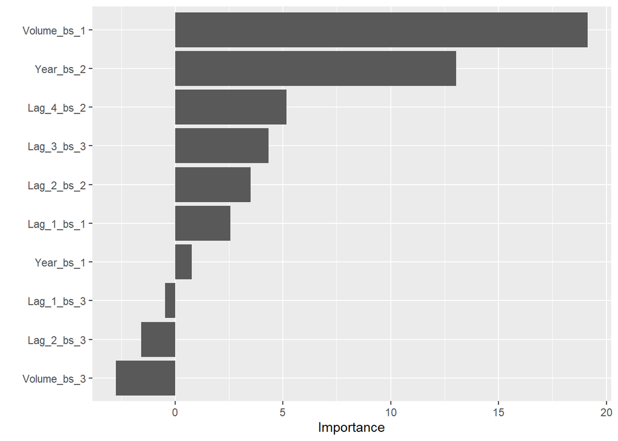

```r
best_enhanced_fit%>%
  extract_fit_parsnip()%>%
  vip()
```

# Confusion Matrix

Both recipes’ matrix are shown but only enhanced recipe is of interest as that is the best model under Neural Networks, more will be discussed in Summary Report

```r
best_neuralnetworks_base_model<-select_best(neuralnetworks_base_tune)
neuralnetworks_base_tune%>%conf_mat_resampled(parameters = best_neuralnetworks_base_model)
```

```
## # A tibble: 4 × 3
##   Prediction Truth  Freq
##   <fct>      <fct> <dbl>
## 1 Down       Down   134.
## 2 Down       Up     132.
## 3 Up         Down   277.
## 4 Up         Up     376.
```

```r
best_neuralnetworks_enhanced_model<-select_best(neuralnetworks_enhanced_tune)
neuralnetworks_enhanced_tune%>%conf_mat_resampled(parameters = best_neuralnetworks_enhanced_model)
```

```
## # A tibble: 4 × 3
##   Prediction Truth  Freq
##   <fct>      <fct> <dbl>
## 1 Down       Down   147
## 2 Down       Up     136.
## 3 Up         Down   264
## 4 Up         Up     372.
```

# Saving Results

Enhanced recipe was the strongest performing model based on the optimization metric (ROC_AUC) so the details relating to it were saved.

```r
save(neuralnetworks_enhanced_metric, best_enhanced_wf, best_enhanced_model,
     file = 'neuralnetworks_enhanced_objects.Rda')
```